# World Energy

Mariana Manzano Rico

2023-04-25

# **Abstract**

Humans are always looking for energy since it is crucial for every process around us, we can’t move, produce, build, or do anything without it, even our bodies need it to survive. That’s why different types of energy around the world exist, some older like petroleum or coal, and other new ones such as solar and wind energy. However, the consumption and production of these energies vary from country to country, it depends on other factors like investment, GDP, equipment, people, research, and obviously, the source to exist in the territory.

We also need to consider that even if energy is crucial for our lives, how people produce it (and use it) is not the best and has big consequences for our environment. Governments, organizations, and enterprises know it and that it must change, so they are looking for new ways and more friendly with the environment to produce energy and take it to every person in the easiest possible way.

# **Introduction**

In this case, we have the next problem situation: A company named AK Nacional del Monte, which provides energy for the retail industry needs to know whether it’s best to produce energy with new and renewable methods, to do it in the old way, or both, specifically for Brazil, Canada, Mexico, Haiti, and Venezuela. We, as data analysts, will consider different variables such as consumption of different energy types, production, intensity, GDP, CO2 emissions, and prices, which will be presented in this report.

# **Objectives**

- Clean the whole databases that will be used for the analysis by following the correct steps in order to don’t make any mistakes and get the most precise information.
- Analyze each variable of the dataset so we can find insights inside that data.
- Comprehend with the help of charts and graphs the information that we are seeing to find patterns in data.
- With the whole analysis, give the best recommendations based on the actual information so the client can take the best decisions to have benefits for his enterprise.

# **Description of the variables**

For this, we will use three databases named Energy, Consumption, and Statistics. The first one gives us information about consumption, production, and data of each country from 1980 to 2019, the second one has information about different energy types such as oil, solar, wind, and other renewables from 1900 to 2019. Finally, the third one gives us information about the transactions made by each country for different commodities such as coal, natural gas, and petroleum from 1990 to 2014. It is important to say that we won’t mention units of measurement because these databases don’t specify it. The next lines are a few of each database:

```
## Rows: 55,440
## Columns: 11
## $ X                           <int> 0, 1, 2, 3, 4, 5, 6, 7, 8, 9, 10, 11, 12, …
## $ Country                     <chr> "World", "World", "World", "World", "World…
## $ Energy_type                 <chr> "all_energy_types", "coal", "natural_gas",…
## $ Year                        <int> 1980, 1980, 1980, 1980, 1980, 1980, 1980, …
## $ Energy_consumption          <dbl> 292.89979, 78.65613, 53.86522, 132.06402, …
## $ Energy_production           <dbl> 296.3372276, 80.1141943, 54.7610456, 133.1…
## $ GDP                         <dbl> 27771, 27771, 27771, 27771, 27771, 27771, …
## $ Population                  <dbl> 4298126.5, 4298126.5, 4298126.5, 4298126.5…
## $ Energy_intensity_per_capita <dbl> 68.15, 68.15, 68.15, 68.15, 68.15, 68.15, …
## $ Energy_intensity_by_GDP     <dbl> 10.5, 10.5, 10.5, 10.5, 10.5, 10.5, 0.0, 0…
## $ CO2_emission                <dbl> 4947, 1410, 1082, 2455, 0, 0, NA, NA, NA, …
```

```
## Rows: 17,432
## Columns: 122
## $ iso_code                                <chr> "AFG", "AFG", "AFG", "AFG", "A…
## $ country                                 <chr> "Afghanistan", "Afghanistan", …
## $ year                                    <int> 1900, 1901, 1902, 1903, 1904, …
## $ coal_prod_change_pct                    <dbl> NA, NA, NA, NA, NA, NA, NA, NA…
## $ coal_prod_change_twh                    <dbl> NA, 0, 0, 0, 0, 0, 0, 0, 0, 0,…
## $ gas_prod_change_pct                     <dbl> NA, NA, NA, NA, NA, NA, NA, NA…
## $ gas_prod_change_twh                     <dbl> NA, NA, NA, NA, NA, NA, NA, NA…
## $ oil_prod_change_pct                     <dbl> NA, NA, NA, NA, NA, NA, NA, NA…
## $ oil_prod_change_twh                     <dbl> NA, NA, NA, NA, NA, NA, NA, NA…
## $ energy_cons_change_pct                  <dbl> NA, NA, NA, NA, NA, NA, NA, NA…
## $ energy_cons_change_twh                  <dbl> NA, NA, NA, NA, NA, NA, NA, NA…
## $ biofuel_share_elec                      <dbl> NA, NA, NA, NA, NA, NA, NA, NA…
## $ biofuel_elec_per_capita                 <dbl> NA, NA, NA, NA, NA, NA, NA, NA…
```

[output cut: 109 more lines]

```
## Rows: 1,189,482
## Columns: 7
## $ country_or_area       <chr> "Austria", "Austria", "Belgium", "Belgium", "Bel…
## $ commodity_transaction <chr> "Additives and Oxygenates - Exports", "Additives…
## $ year                  <int> 1996, 1995, 2014, 2013, 2012, 2011, 2010, 2009, …
## $ unit                  <chr> "Metric tons,  thousand", "Metric tons,  thousan…
## $ quantity              <dbl> 5, 17, 0, 0, 35, 25, 22, 45, 1, 7, 9, 13, 39, 21…
## $ quantity_footnotes    <int> NA, NA, NA, NA, NA, NA, NA, NA, NA, NA, NA, NA, …
## $ category              <chr> "additives_and_oxygenates", "additives_and_oxyge…
```

However, these databases must be cleaned to make a good analysis of each variable. In this report we won’t give deep explanations of what we did because it is not the main purpose, however, it is necessary to understand what we did to clean the databases and the decisions we took based on what to understand the origin of the final databases.

We did the cleansing process for each database as it is seen in the following lines.

# **Cleansing Data Bases and Selecting Data**

### **Data Type**

First, we had to change the data type of some variables, from numeric to factor or from character to numeric, for each database. The next tables show the final data type for each column.

**Energy**

```
## Rows: 55,440
## Columns: 11
## $ X                           <int> 0, 1, 2, 3, 4, 5, 6, 7, 8, 9, 10, 11, 12, …
## $ Country                     <fct> "World", "World", "World", "World", "World…
## $ Energy_type                 <fct> all_energy_types, coal, natural_gas, petro…
## $ Year                        <fct> 1980, 1980, 1980, 1980, 1980, 1980, 1980, …
## $ Energy_consumption          <dbl> 292.89979, 78.65613, 53.86522, 132.06402, …
## $ Energy_production           <dbl> 296.3372276, 80.1141943, 54.7610456, 133.1…
## $ GDP                         <dbl> 27771, 27771, 27771, 27771, 27771, 27771, …
## $ Population                  <dbl> 4298126.5, 4298126.5, 4298126.5, 4298126.5…
## $ Energy_intensity_per_capita <dbl> 68.15, 68.15, 68.15, 68.15, 68.15, 68.15, …
## $ Energy_intensity_by_GDP     <dbl> 10.5, 10.5, 10.5, 10.5, 10.5, 10.5, 0.0, 0…
## $ CO2_emission                <dbl> 4947, 1410, 1082, 2455, 0, 0, NA, NA, NA, …
```

**Consumption**

```
## Rows: 17,432
## Columns: 8
## $ iso_code                    <fct> AFG, AFG, AFG, AFG, AFG, AFG, AFG, AFG, AF…
## $ country                     <fct> Afghanistan, Afghanistan, Afghanistan, Afg…
## $ year                        <fct> 1900, 1901, 1902, 1903, 1904, 1905, 1906, …
## $ oil_consumption             <dbl> NA, NA, NA, NA, NA, NA, NA, NA, NA, NA, NA…
## $ other_renewable_consumption <dbl> NA, NA, NA, NA, NA, NA, NA, NA, NA, NA, NA…
## $ renewables_consumption      <dbl> NA, NA, NA, NA, NA, NA, NA, NA, NA, NA, NA…
## $ wind_consumption            <dbl> NA, NA, NA, NA, NA, NA, NA, NA, NA, NA, NA…
## $ solar_consumption           <dbl> NA, NA, NA, NA, NA, NA, NA, NA, NA, NA, NA…
```

**Statistics**

```
## Rows: 1,189,482
## Columns: 6
## $ country_or_area       <fct> "Austria", "Austria", "Belgium", "Belgium", "Bel…
## $ commodity_transaction <fct> "Additives and Oxygenates - Exports", "Additives…
## $ year                  <fct> 1996, 1995, 2014, 2013, 2012, 2011, 2010, 2009, …
## $ unit                  <fct> "Metric tons,  thousand", "Metric tons,  thousan…
## $ quantity              <dbl> 5, 17, 0, 0, 35, 25, 22, 45, 1, 7, 9, 13, 39, 21…
## $ category              <fct> additives_and_oxygenates, additives_and_oxygenat…
```

### **Filter Data**

At this point, we decided to select only the crucial data for our analysis, this means that we only select the countries that we will study in this report (Brazil, Canada, Venezuela, Mexico, and Haiti).

The final databases are the following ones:

```
##     X Country               Energy_type Year Energy_consumption
## 1 156  Brazil          all_energy_types 1980             3.8964
## 2 157  Brazil                      coal 1980             0.2137
## 3 158  Brazil               natural_gas 1980             0.0566
## 4 159  Brazil petroleum_n_other_liquids 1980             2.2569
## 5 160  Brazil                   nuclear 1980                 NA
## 6 161  Brazil        renewables_n_other 1980             1.3691
##   Energy_production  GDP Population Energy_intensity_per_capita
## 1            1.9807 1305     121051                        32.2
## 2            0.0835 1305     121051                        32.2
## 3            0.0566 1305     121051                        32.2
## 4            0.4030 1305     121051                        32.2
## 5                NA 1305     121051                        32.2
## 6            1.4375 1305     121051                        32.2
##   Energy_intensity_by_GDP CO2_emission
## 1                    2.99           NA
## 2                    2.99           NA
## 3                    2.99           NA
## 4                    2.99           NA
## 5                    2.99            0
## 6                    2.99            0
```

```
##   iso_code country year oil_consumption other_renewable_consumption
## 1      BRA  Brazil 1900              NA                          NA
## 2      BRA  Brazil 1901              NA                          NA
## 3      BRA  Brazil 1902              NA                          NA
## 4      BRA  Brazil 1903              NA                          NA
## 5      BRA  Brazil 1904              NA                          NA
## 6      BRA  Brazil 1905              NA                          NA
##   renewables_consumption wind_consumption solar_consumption
## 1                     NA               NA                NA
## 2                     NA               NA                NA
## 3                     NA               NA                NA
## 4                     NA               NA                NA
## 5                     NA               NA                NA
## 6                     NA               NA                NA
```

```
##   country_or_area                     commodity_transaction year
## 1          Mexico Brown coal briquettes - final consumption 2014
## 2          Mexico Brown coal briquettes - final consumption 2013
## 3          Mexico Brown coal briquettes - final consumption 2012
## 4          Canada            Brown coal - final consumption 2014
## 5          Canada            Brown coal - final consumption 2013
## 6          Canada            Brown coal - final consumption 2012
##                     unit quantity              category
## 1 Metric tons,  thousand        3 brown_coal_briquettes
## 2 Metric tons,  thousand        4 brown_coal_briquettes
## 3 Metric tons,  thousand        4 brown_coal_briquettes
## 4 Metric tons,  thousand     2044            brown_coal
## 5 Metric tons,  thousand     1128            brown_coal
## 6 Metric tons,  thousand     1002            brown_coal
```

### **Uniqueness Restrictions**

We also needed to know if there were complete or partial duplications of registries, but we found there are not any duplicates, so we didn’t have to do anything more in this step.

### **Category review**

The category review means every category to be correctly presented in the database (for example, having `natural_gas` and `Natural_gas` is not the same in R). We checked each category of each database in order to confirm we don’t have to do any category collapse. However, we found we don’t have any problems related to categories.

### **Missing Data**

The biggest problem that we found in these databases is the missing data, so we had to do a really hard work to complete the data and do it correctly. This is the section in which we will explain most of the corrections we made and the decisions we took.

First, we calculate the number of NAs in each database as well as the proportion.

**Energy**

```
## [1] 252
```

```
## [1] 0.0191
```

**Consumption**

```
## [1] 1515
```

```
## [1] 0.362
```

**Statistics**

```
## [1] 0
```

```
## [1] 0
```

In Statistics we see there are no NAs, so we won’t change anything until next steps.

#### **Imputation**

The most important part of this section is the imputation. To this, we applied different imputation models in new objects and then evaluated them with the Linear Regression method.

##### **Final imputation**

The criteria we used to select the best imputation model was with the lowest std.error, which was, in both cases, the “Below the Range” method. However, in consumption, we supposed that if there is no data in those countries or years, it is because that kind of energy is not or wasn’t used, so we applied the “0s” method (change all NAs values to 0s) to have a more precise data.

### **Outliers**

Finally, we looked for the outliers in each database and change them for the highest or lowest values that are not considered outliers (values that we calculated). In statistics, we didn’t do this because, if we see the database, we notice that the quantities are not valued in the same units (some refer to terajoules, others to million tons, etc), so we can’t change outliers in that database.

# **Analysis**

After the data cleansing, we are going to analyze all this information through tables and graphs, to look for patterns, and insights and take decisions.

### **Energy Consumption**

First, we want to know what is happening in the variable Energy Consumption from the database Energy, to understand how the selected countries consume some of the energies found in this data frame. The energies presented in this data are:

- Coal
- Natural Gas
- Nuclear
- Petroleum and other liquids
- Renewables and others.

We will also see information from 1980 to 2019 from Brazil, Canada, Mexico, Haiti, and Venezuela.

#### **Mean and Standard Deviation**

First, we want to know the mean and standard deviation of all countries and energies, so then we can understand the difference between energies.

```
## [1] 1.88
```

```
## [1] 2.65
```

We saw that the mean is 1.88 and the standard deviation of 2.65.

**For each country**

However, it is also important to see this information divided by country.

```
## # A tibble: 5 × 2
##   Country      mean
##   <fct>       <dbl>
## 1 Canada    2.47
## 2 Brazil    1.64
## 3 Mexico    1.24
## 4 Venezuela 0.510
## 5 Haiti     0.00524
```

```
## # A tibble: 5 × 2
##   Country       sd
##   <fct>      <dbl>
## 1 Brazil    1.79
## 2 Mexico    1.42
## 3 Canada    1.40
## 4 Venezuela 0.483
## 5 Haiti     0.0107
```

We see that the country with the most consumption is Canada, then Brazil, and in the last place is Haiti with a big difference between the first one.

**By country and Energy type**

Finally, we look for the mean and standard deviation divided by country and energy type and ordered this data from the highest consumption to the less.

```
## # A tibble: 25 × 3
## # Groups:   Country [5]
##    Country   Energy_type                mean
##    <fct>     <fct>                     <dbl>
##  1 Canada    petroleum_n_other_liquids 4.06
##  2 Brazil    petroleum_n_other_liquids 3.95
##  3 Mexico    petroleum_n_other_liquids 3.71
##  4 Canada    renewables_n_other        3.37
##  5 Brazil    renewables_n_other        3.15
##  6 Canada    natural_gas               3.07
##  7 Mexico    natural_gas               1.73
##  8 Venezuela petroleum_n_other_liquids 1.06
##  9 Canada    coal                      0.964
## 10 Venezuela natural_gas               0.947
## # … with 15 more rows
```

```
## # A tibble: 25 × 3
## # Groups:   Country [5]
##    Country   Energy_type                  sd
##    <fct>     <fct>                     <dbl>
##  1 Brazil    petroleum_n_other_liquids 1.42
##  2 Brazil    renewables_n_other        1.04
##  3 Canada    natural_gas               0.788
##  4 Canada    petroleum_n_other_liquids 0.728
##  5 Mexico    natural_gas               0.722
##  6 Brazil    natural_gas               0.470
##  7 Mexico    petroleum_n_other_liquids 0.454
##  8 Canada    renewables_n_other        0.358
##  9 Venezuela petroleum_n_other_liquids 0.278
## 10 Venezuela renewables_n_other        0.207
## # … with 15 more rows
```

Canada, Brazil, and Mexico have the most consumption of petroleum, and Haiti has the less in renewables and coal. We also discovered that Haiti doesn’t consume Natural Gas and Nuclear as well as Venezuela.

#### **Distribution**

It is also important to understand the distribution of the data, so we did the following graphs to visualize it.

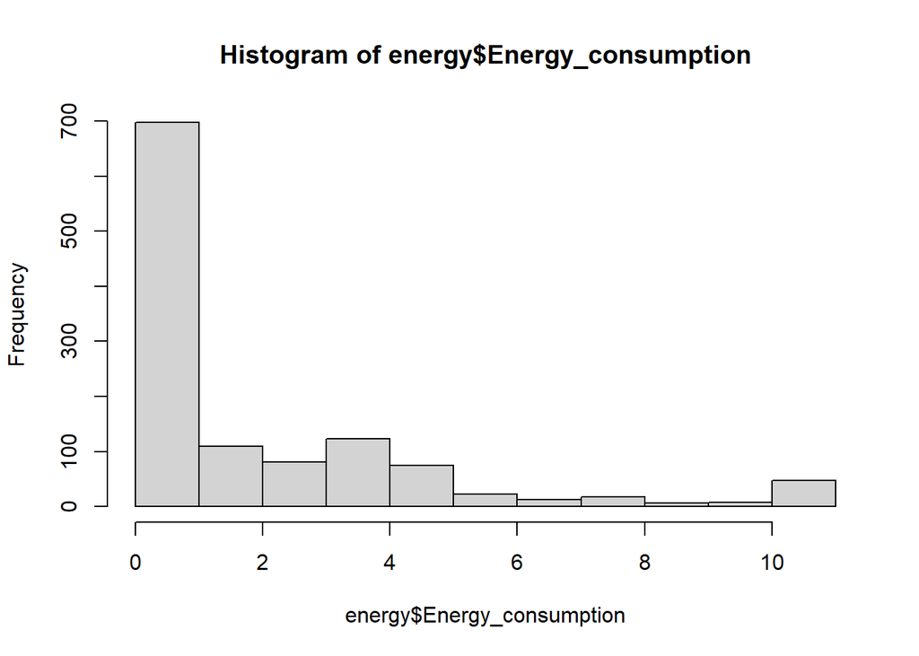

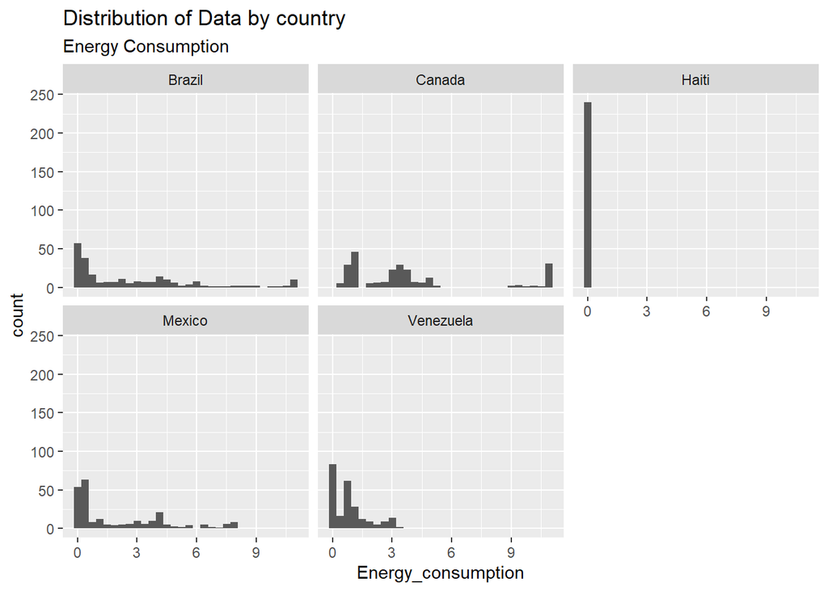

#### **Use of energy in the last year registered for each country**

To visualize in proportions how much consume each country in each energy type, we did the next pie chart, where we discovered that petroleum is the most consumed energy, Haiti has only petroleum and renewable energy, and the second most consumed is natural gas.

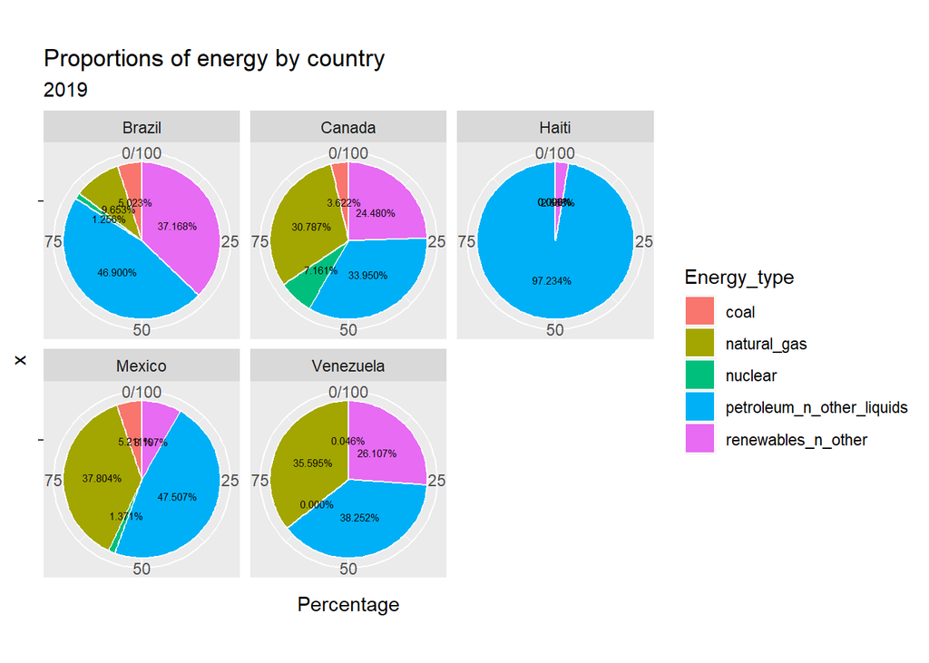

#### **Growth**

The consumption growth of each energy in every country is important to analyze, it will give us information about how much investment and publicity of each energy was made in each country through the years.

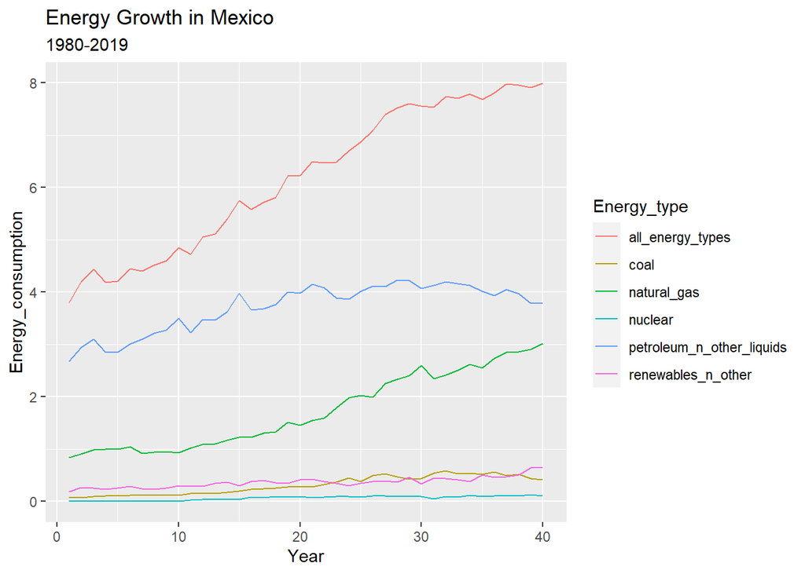

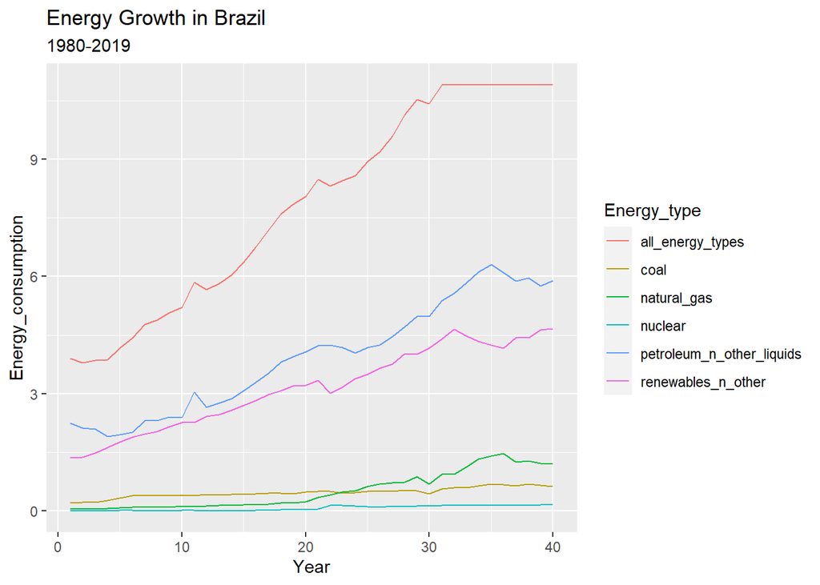

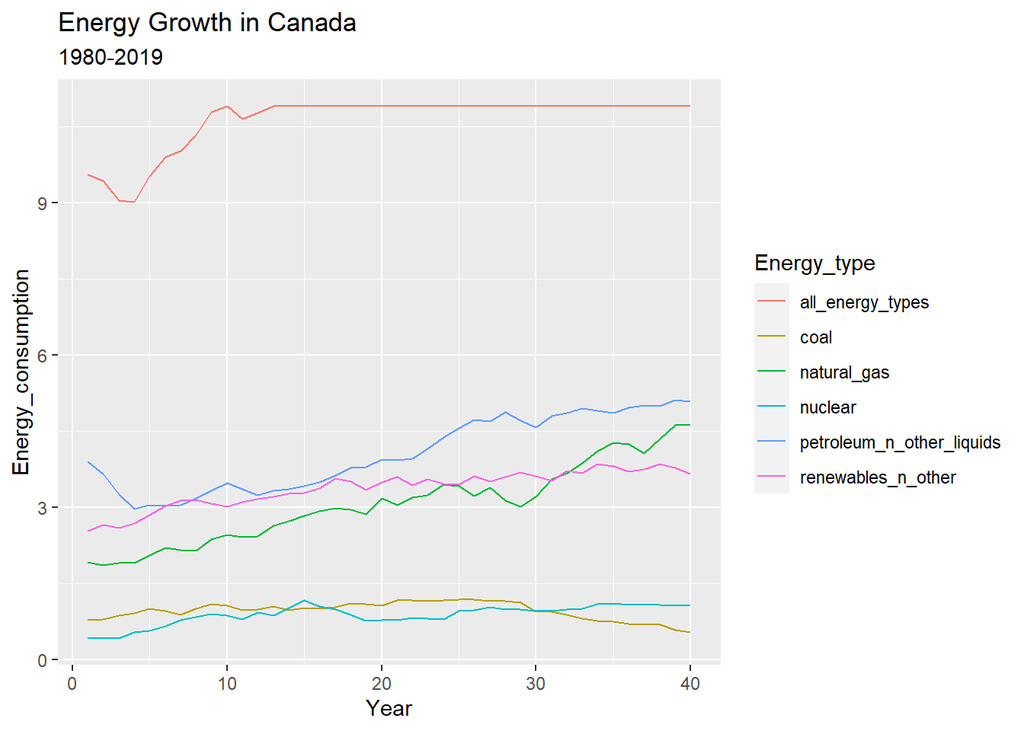

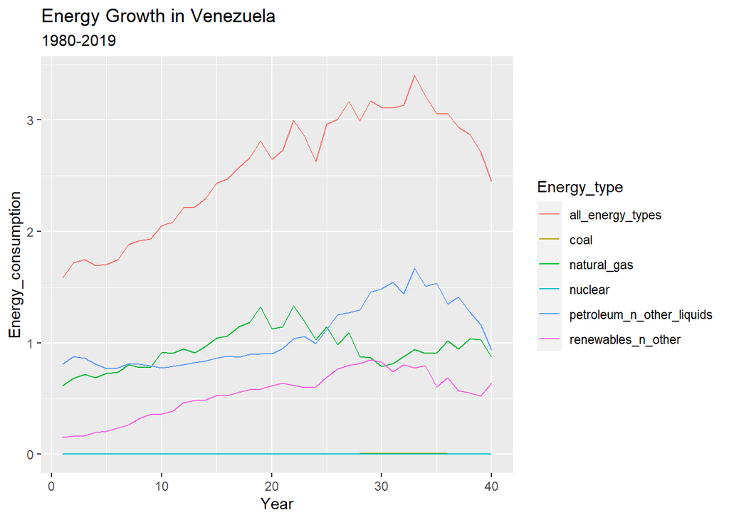

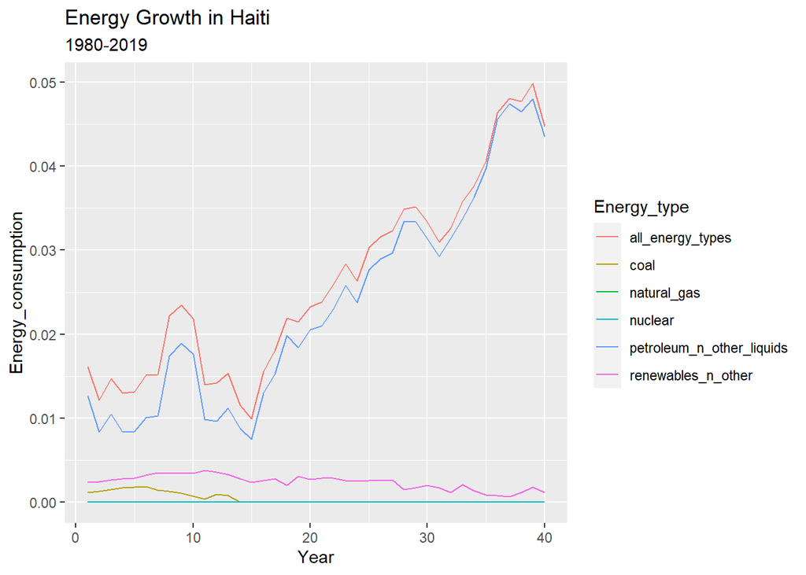

In Mexico, Natural Gas presents the highest growth, petroleum had a little but started to descend and the other energies doesn’t present a down but neither a growth. In Brazil, Petroleum and renewables had a growth, also Natural Gas but the consumption is less. Canada had a little increase in petroleum and in Natural Gas. Venezuela had a growth in petroleum but then went down, also the same happened with Natural Gas and Renewables but at different times. Finally, in Haiti, the growth of all energies is almost represented only by petroleum with had a very big increase through the years.

### **Energy production**

The other variable we are going to analyze is `Energy_production`, so we can know how much energy is produced in each country and know which ones have the infrastructure to produce it, which ones had an increase, and in which ones we can invest in order to have the highest earnings.

#### **Mean and Standard Deviation**

Again, we want to know the mean and standard deviation, which in this case are 2.48 and 3.48 respectively.

```
## [1] 2.48
```

```
## [1] 3.48
```

**For each country**

Divided by country, Canada again is the biggest producer, and Haiti the smallest. Mexico is in second place.

```
## # A tibble: 5 × 2
##   Country       mean
##   <fct>        <dbl>
## 1 Canada    3.32
## 2 Mexico    1.66
## 3 Venezuela 1.40
## 4 Brazil    1.35
## 5 Haiti     0.000481
```

```
## # A tibble: 5 × 2
##   Country        sd
##   <fct>       <dbl>
## 1 Mexico    2.44
## 2 Canada    2.26
## 3 Venezuela 2.12
## 4 Brazil    1.74
## 5 Haiti     0.00103
```

**By country and Energy type**

We also discovered that Mexico had been the biggest producer of petroleum and followed by Canada and Venezuela, then Canada with Natural Gas, and in the last places we see Mexico with Nuclear energy and Haiti with renewables.

```
## # A tibble: 25 × 3
## # Groups:   Country [5]
##    Country   Energy_type                mean
##    <fct>     <fct>                     <dbl>
##  1 Mexico    petroleum_n_other_liquids 6.37
##  2 Canada    petroleum_n_other_liquids 5.69
##  3 Venezuela petroleum_n_other_liquids 5.43
##  4 Canada    natural_gas               5.19
##  5 Canada    renewables_n_other        3.49
##  6 Brazil    renewables_n_other        3.41
##  7 Brazil    petroleum_n_other_liquids 2.85
##  8 Canada    coal                      1.36
##  9 Mexico    natural_gas               1.31
## 10 Venezuela natural_gas               0.937
## # … with 15 more rows
```

```
## # A tibble: 25 × 3
## # Groups:   Country [5]
##    Country   Energy_type                  sd
##    <fct>     <fct>                     <dbl>
##  1 Canada    petroleum_n_other_liquids 2.09
##  2 Brazil    petroleum_n_other_liquids 1.74
##  3 Canada    natural_gas               1.45
##  4 Brazil    renewables_n_other        1.18
##  5 Venezuela petroleum_n_other_liquids 1.15
##  6 Mexico    petroleum_n_other_liquids 0.988
##  7 Canada    renewables_n_other        0.391
##  8 Mexico    natural_gas               0.344
##  9 Brazil    natural_gas               0.259
## 10 Venezuela renewables_n_other        0.209
## # … with 15 more rows
```

#### **Distribution**

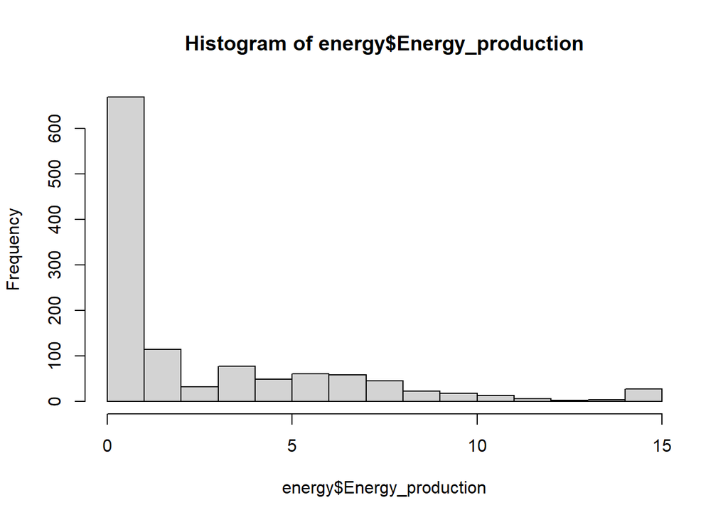

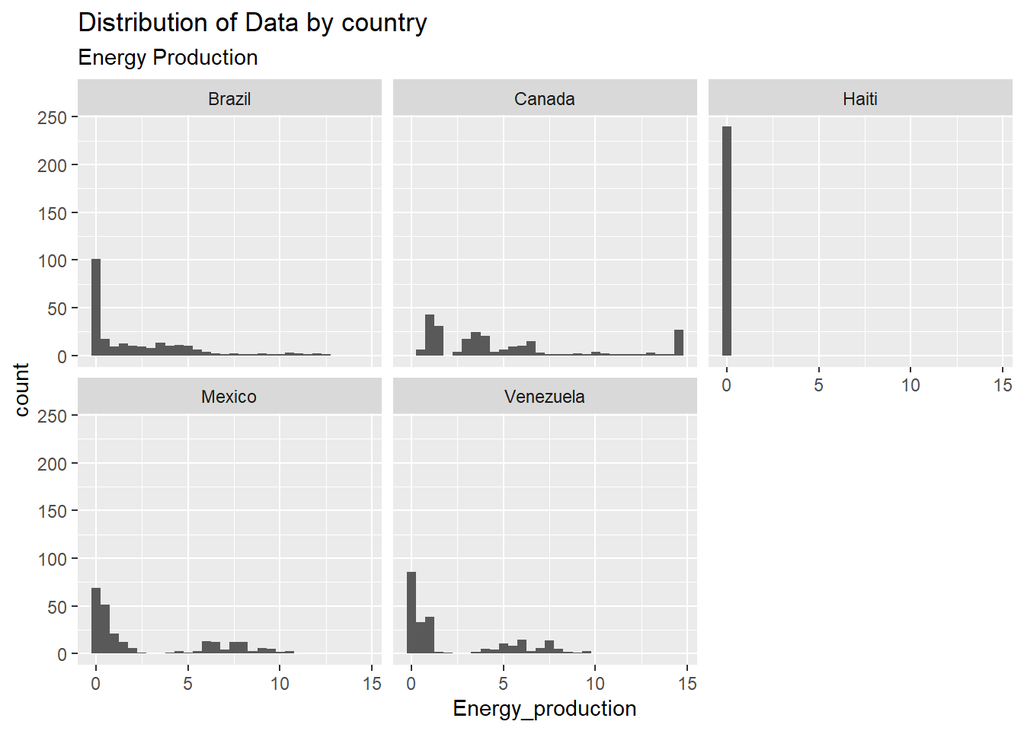

#### **Production of energy in the last year registered for each country**

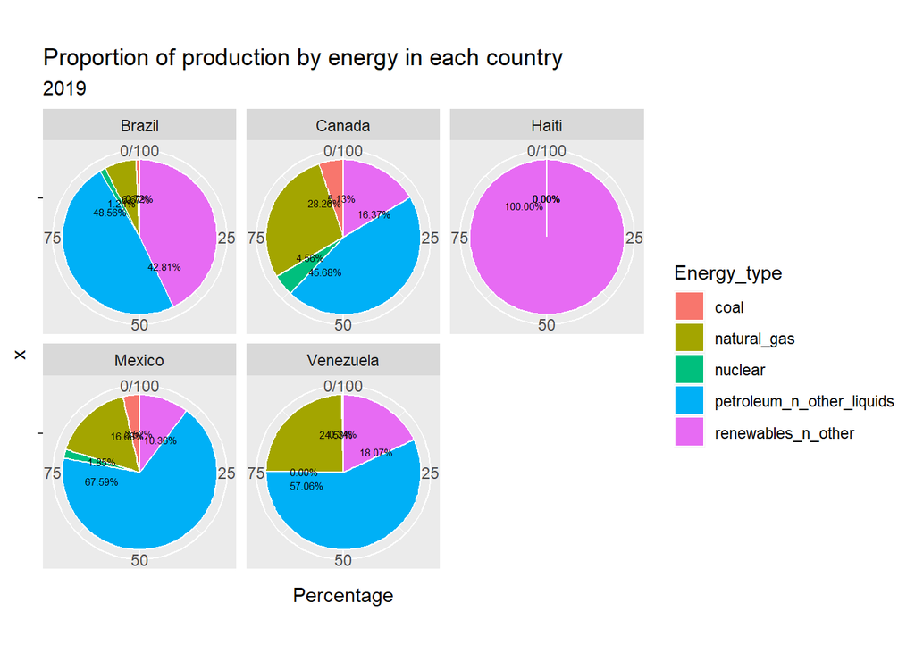

#### **Growth**

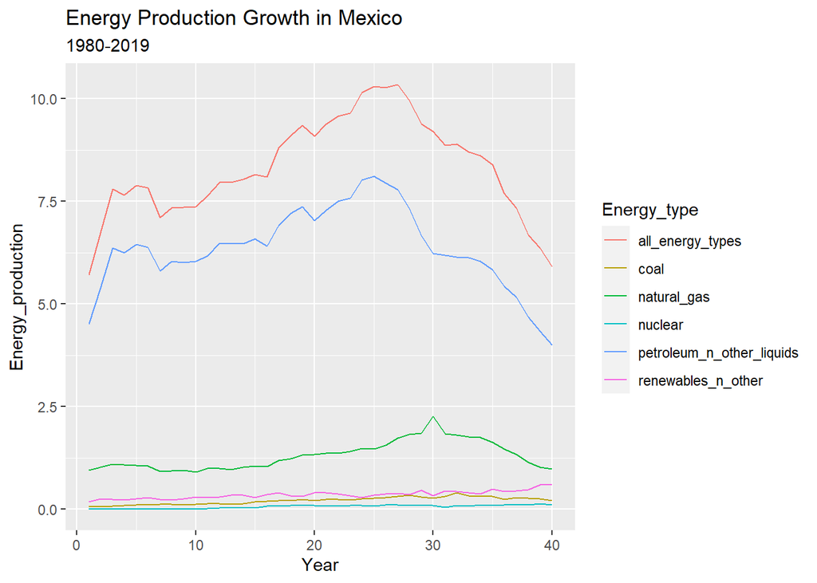

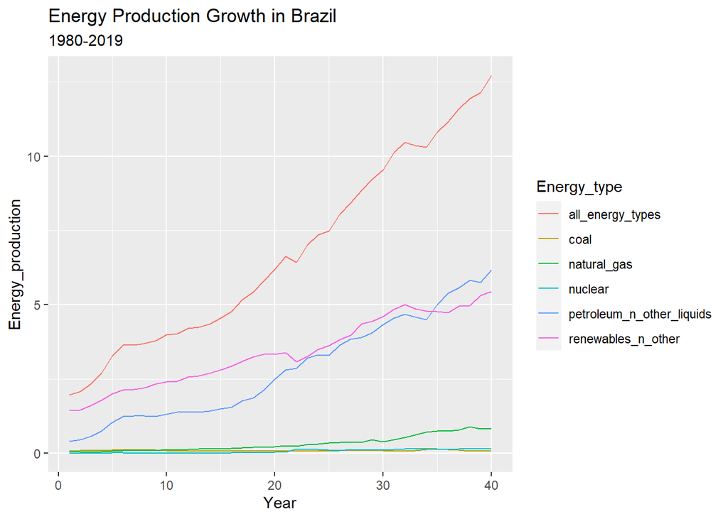

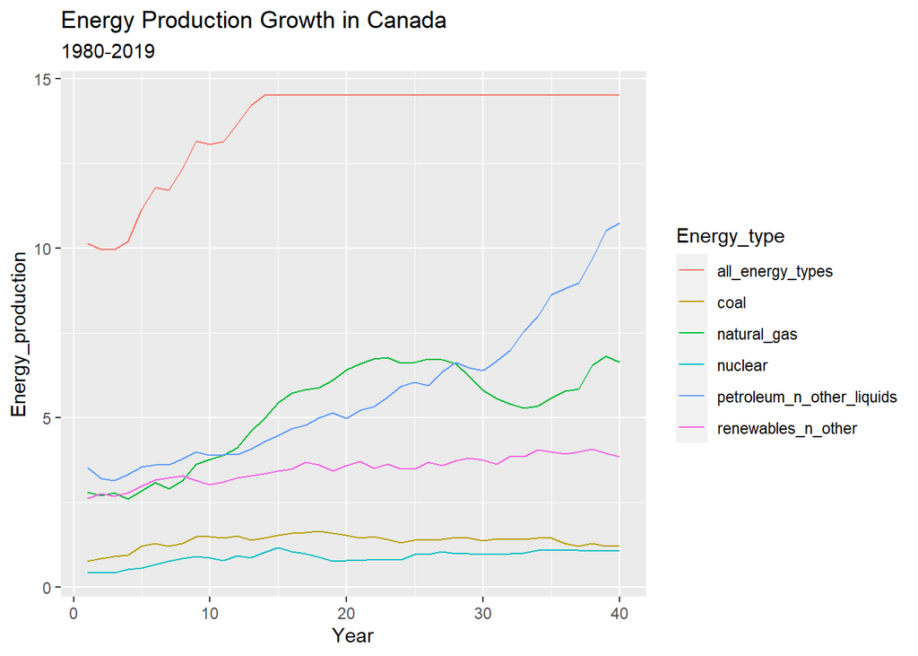

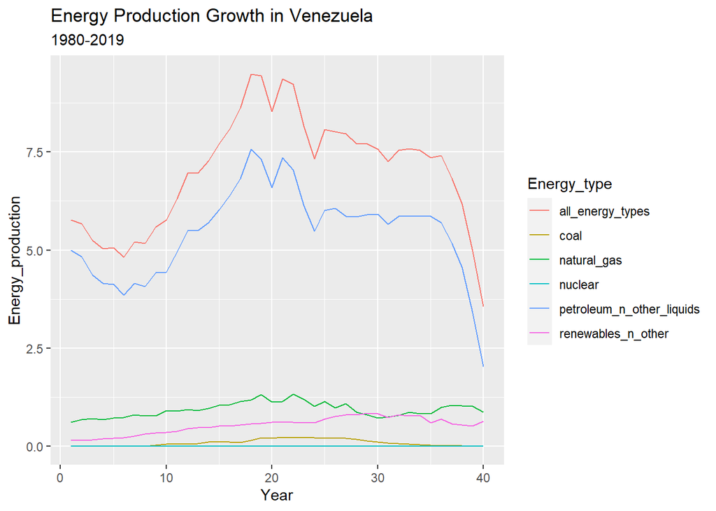

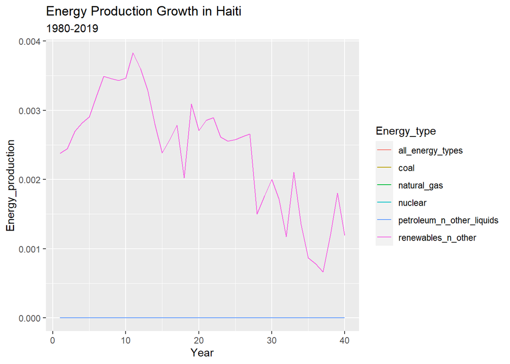

Analyzing the production growth in each country, we found that in Mexico, petroleum production had decreased in the last years and natural gas started to grow but then went down. Brazil presented a high increase in petroleum and renewables. Canada had a growth in petroleum and a particular behavior in natural gas. Venezuela had a very big decrease in petroleum and Haiti had a high in renewables but started to have a decrease in the last years.

### **GDP**

It is also important to analyze the GDP by country to see its behavior and in which one is most safe to invest in. We did almost the same calculations as in the other two variables.

#### **Mean and Standard Deviation**

```
## [1] 1052
```

```
## [1] 852
```

First, the total mean and standard deviation. The mean is 1052 and the standard deviation is 852.

**For each country**

```
## # A tibble: 5 × 2
##   Country     mean
##   <fct>      <dbl>
## 1 Brazil    2097.
## 2 Mexico    1598.
## 3 Canada    1166.
## 4 Venezuela  380.
## 5 Haiti       21.4
```

```
## # A tibble: 5 × 2
##   Country      sd
##   <fct>     <dbl>
## 1 Brazil    634.
## 2 Mexico    441.
## 3 Canada    322.
## 4 Venezuela  96.1
## 5 Haiti      11.0
```

Here we see unexpected things, Brazil has the highest GDP, then Mexico, Canada, Venezuela, and finally Haiti.

#### **Distribution**

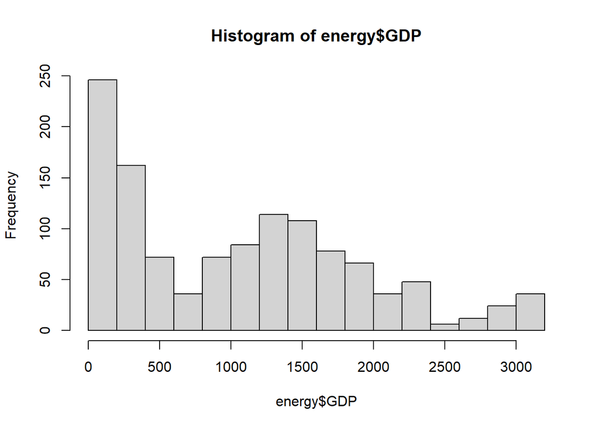

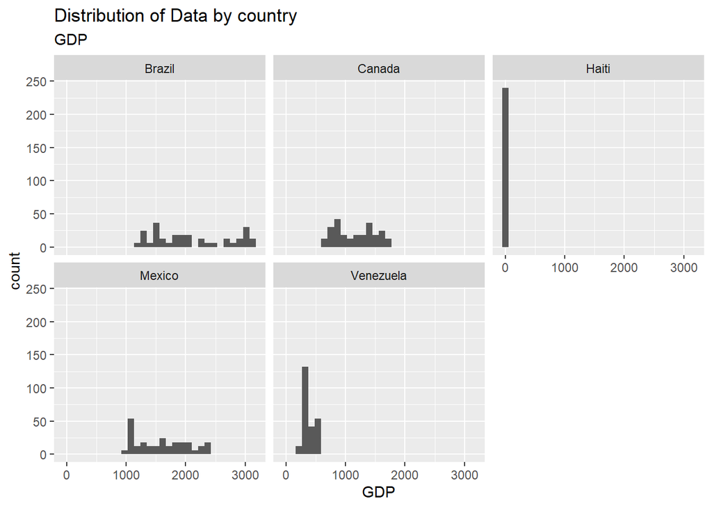

#### **GDP of each country**

Then we see the proportions of GDP in the last year (2019), where Brazil has the highest, then Mexico, Canada, Venezuela, and finally, Haiti is almost invisible. This affirms that maybe the safer place to invest in is Brazil, then Mexico, and finally Canada.

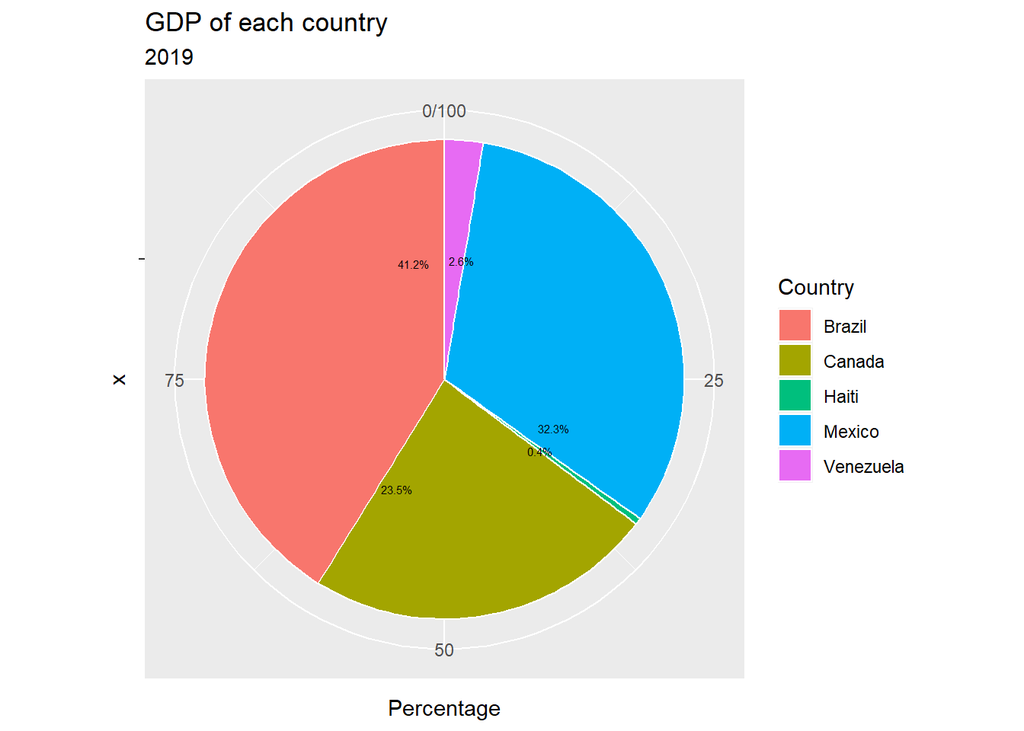

#### **Growth**

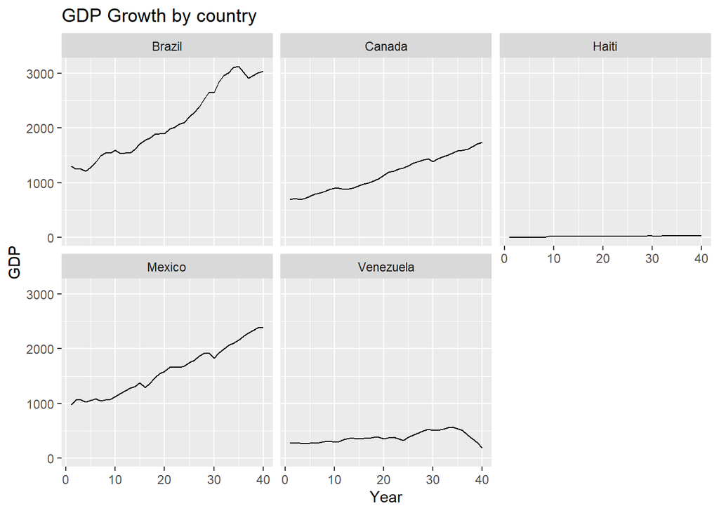

Finally, we visualize the GDP growth in each country. Brazil has the highest increase, then Mexico and finally Canada. Venezuela, by contrast, had a decrease and Haiti almost maintained the same.With this, we can suppose that Brazil will have better development in the following years.

### **Energy intensity by GDP**

Then we will analyze the `Energy_intensity_by_GDP` variable, where we are going to understand the use of energy depending on the GDP by country.

#### **Mean and Standard Deviation**

The mean, in this case, is 5.29, while the standard deviation is 3.55, talking about total countries and energies.

```
## [1] 5.29
```

```
## [1] 3.55
```

**For each country**

Divided by country, we notice that the highest intensity depending on GDP is in Canada and then Venezuela. Haiti again is in the last place.

```
## # A tibble: 5 × 2
##   Country     mean
##   <fct>      <dbl>
## 1 Canada    11.0
## 2 Venezuela  6.86
## 3 Mexico     3.93
## 4 Brazil     3.81
## 5 Haiti      0.843
```

```
## # A tibble: 5 × 2
##   Country      sd
##   <fct>     <dbl>
## 1 Canada    1.45
## 2 Venezuela 1.26
## 3 Haiti     0.508
## 4 Brazil    0.398
## 5 Mexico    0.252
```

#### **Distribution**

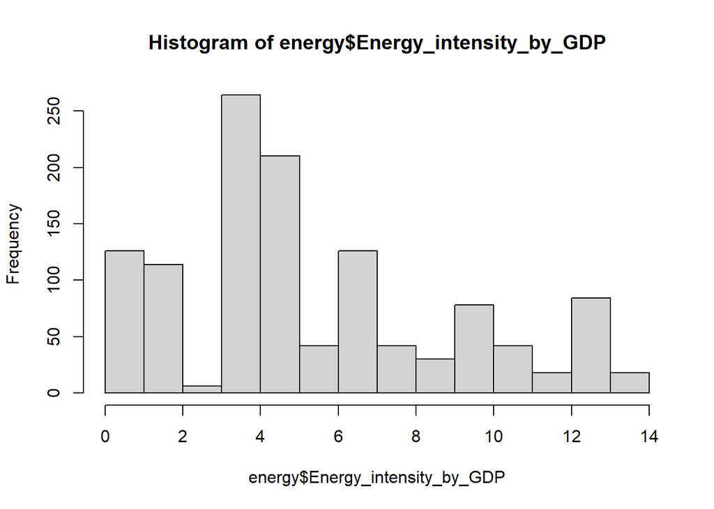

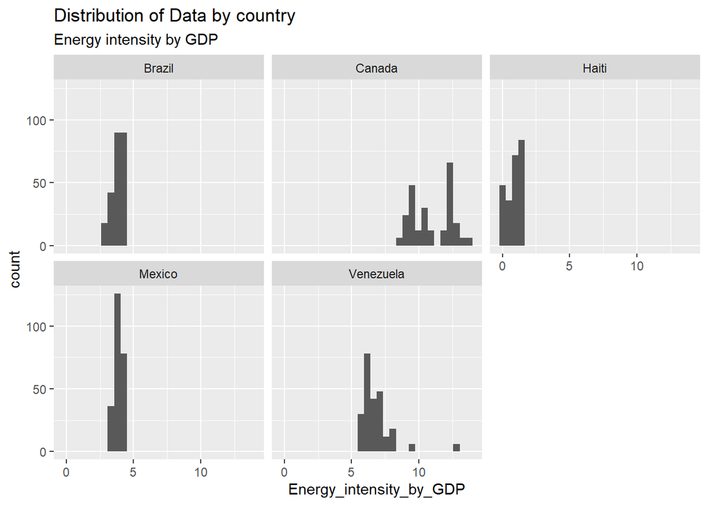

#### **Growth**

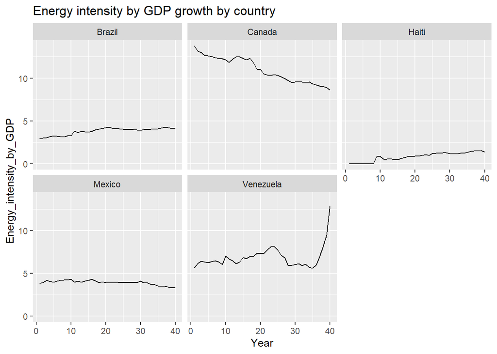

### **CO2 Emissions**

The last variable we will analyze in this database is `CO2_emissions`, where we will find how much pollution produces each energy.

#### **Mean and Standard Deviation**

The total mean, no matter countries or energies, is 83.6, while its standard deviation is 129. This means there is a lot of variability through registries or that every energy produces different quantities of emissions.

```
## [1] 83.6
```

```
## [1] 129
```

**For each country**

```
## # A tibble: 5 × 2
##   Country     mean
##   <fct>      <dbl>
## 1 Canada    98.1
## 2 Mexico    70.0
## 3 Brazil    62.6
## 4 Venezuela 23.7
## 5 Haiti      0.317
```

```
## # A tibble: 5 × 2
##   Country       sd
##   <fct>      <dbl>
## 1 Canada    99.0
## 2 Brazil    97.2
## 3 Mexico    92.8
## 4 Venezuela 31.3
## 5 Haiti      0.733
```

Talking about countries, Canada is the country that produced the most pollution thanks to its energies, then is followed by Mexico, Brazil, Venezuela and finally Haiti, with almost any emissions.

**By country and Energy type**

```
## # A tibble: 25 × 3
## # Groups:   Country [5]
##    Country   Energy_type                mean
##    <fct>     <fct>                     <dbl>
##  1 Canada    petroleum_n_other_liquids 242.
##  2 Brazil    petroleum_n_other_liquids 239.
##  3 Mexico    petroleum_n_other_liquids 232.
##  4 Canada    natural_gas               157.
##  5 Canada    coal                       92.2
##  6 Mexico    natural_gas                87.9
##  7 Venezuela petroleum_n_other_liquids  68.8
##  8 Venezuela natural_gas                49.1
##  9 Brazil    coal                       47.7
## 10 Mexico    coal                       30.1
## # … with 15 more rows
```

```
## # A tibble: 25 × 3
## # Groups:   Country [5]
##    Country   Energy_type                  sd
##    <fct>     <fct>                     <dbl>
##  1 Brazil    petroleum_n_other_liquids  75.8
##  2 Mexico    petroleum_n_other_liquids  56.4
##  3 Canada    petroleum_n_other_liquids  54.3
##  4 Canada    natural_gas                47.1
##  5 Mexico    natural_gas                39.4
##  6 Brazil    natural_gas                24.6
##  7 Canada    coal                       20.9
##  8 Venezuela petroleum_n_other_liquids  19.8
##  9 Mexico    coal                       17.3
## 10 Brazil    coal                       15.2
## # … with 15 more rows
```

Divided by countries and energy types, Canada, Brazil, and Mexico are the ones who produced the most pollution with petroleum. The last places are Venezuela with Coal and Haiti with coal and natural gas. However, this is also thanks to that, in those places, the production and consumption of those energy types are low. In the end, there are some places that don’t produce any CO2 emission with some energies, this might happen because in those places they don’t produce and consume them. However, there are some places that have these energies and still not polluting, which are:

- Brazil with renewables.
- Canada with nuclear and renewables.
- Mexico with nuclear and renewables.
- Venezuela with renewables.

This tells us that these energies in those countries are friendly to the environment and are well managed in order to don’t produce pollution.

#### **Distribution**

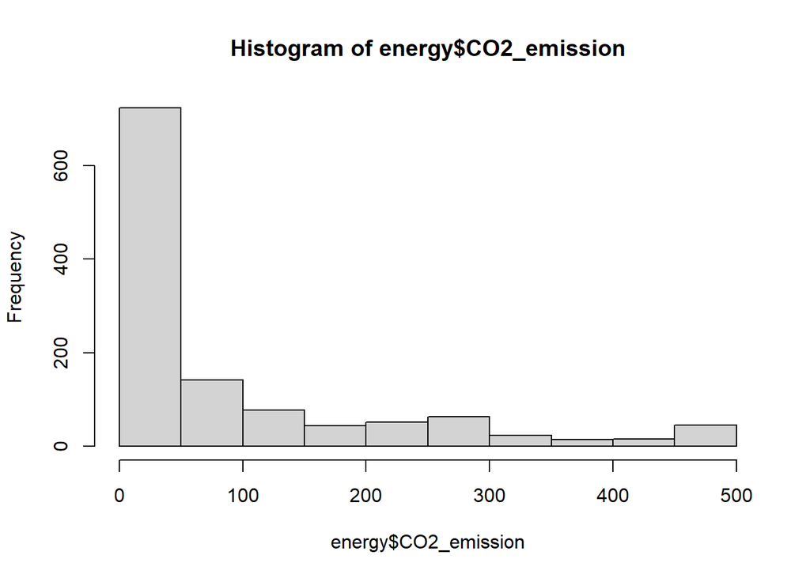

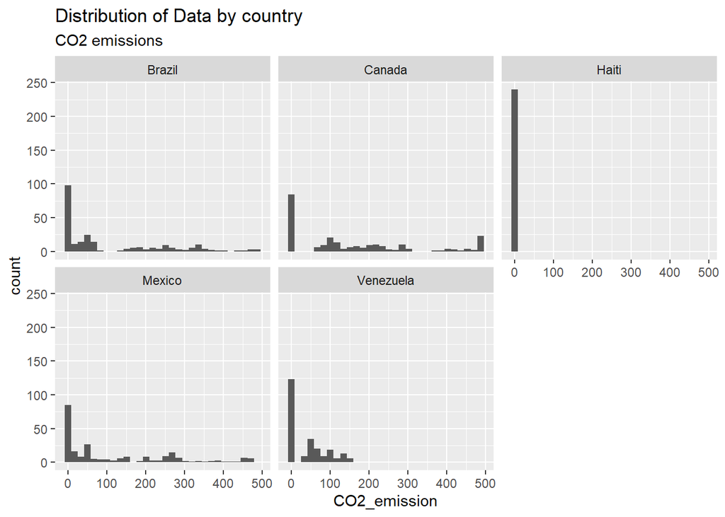

#### **CO2 emissions per energy in the last recorded year for each country**

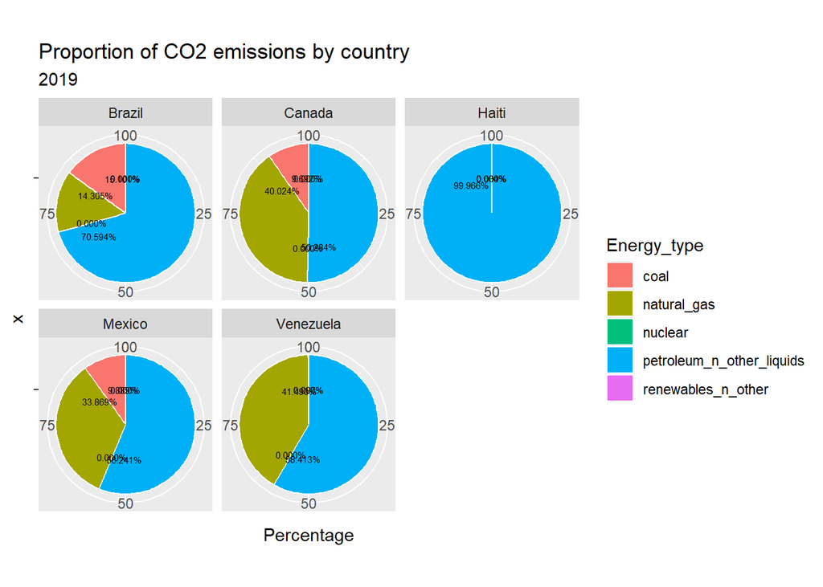

#### **Growth**

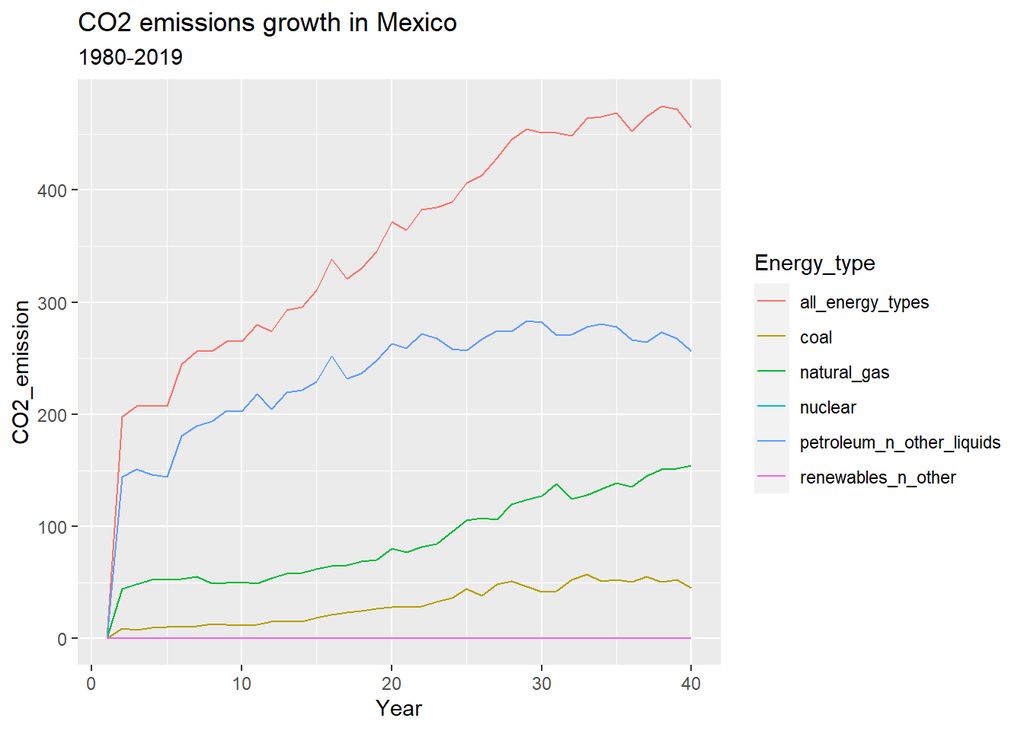

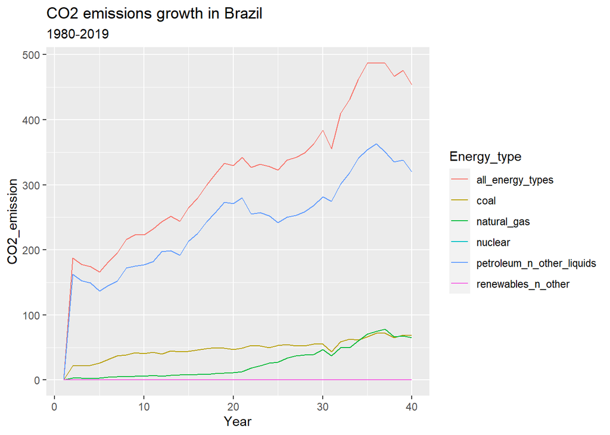

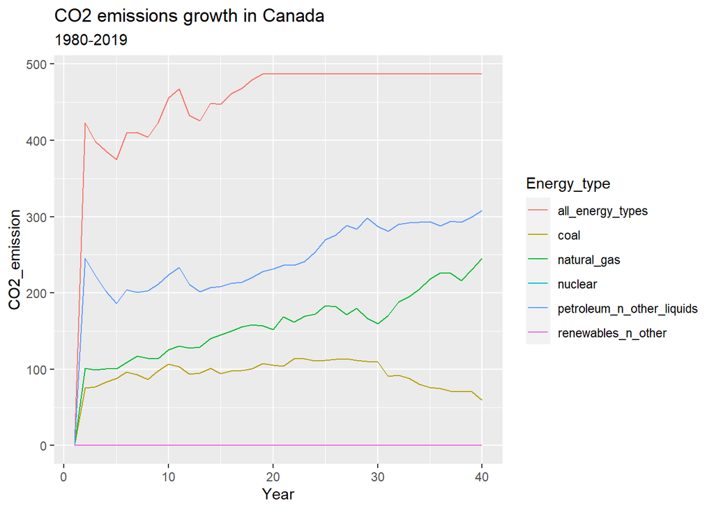

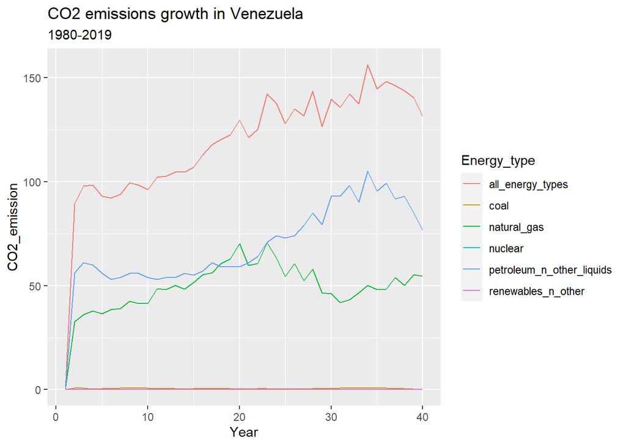

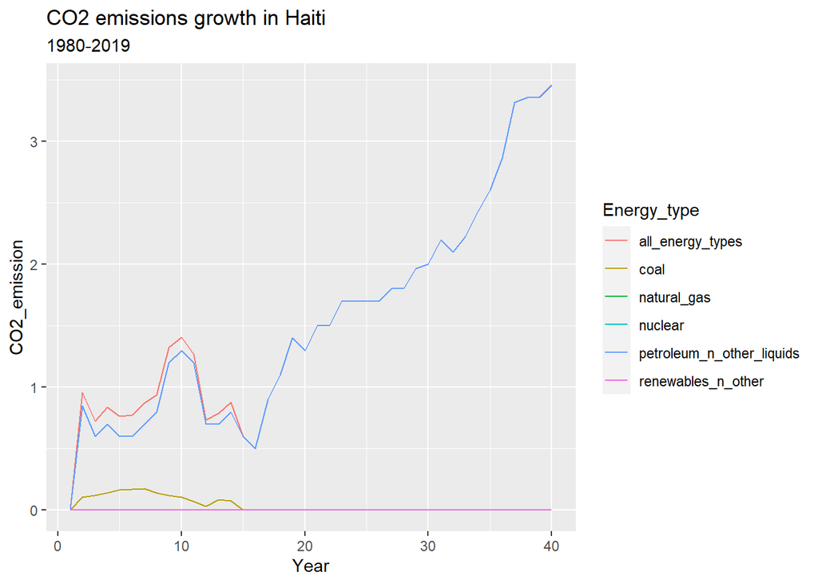

The growth of emissions by energy type in each country is in these graphs, where we notice that in Mexico, the emissions produced by petroleum are stable and the ones of natural gas had a growth. In Brazil, the emissions of petroleum had a very big growth and the ones of natural gas also did but not at the same dimension. In Canada, petroleum had little growth, and natural as well and coal decreased. In Venezuela, an increase in petroleum and natural gas went down. Finally, the emissions of petroleum in Haiti had a very big growth, renewables stayed and coal decreased.